# Chapter 11 - Removing Trend

# Removing Trend

So far our analysis of the diamonds data has been plagued by the powerful relationship between size (carat) and price

It makes it very difficult to see the impact of cut, colour and clarity because higher quality diamonds tend to be smaller, and hence cheaper

```
     carat               cut        color        clarity          depth           table           price
 Min.   :0.2000   Fair     : 1610   D: 6775   SI1    :13065   Min.   :43.00   Min.   :43.00   Min.   :  326
 1st Qu.:0.4000   Good     : 4906   E: 9797   VS2    :12258   1st Qu.:61.00   1st Qu.:56.00   1st Qu.:  950
 Median :0.7000   Very Good:12082   F: 9542   SI2    : 9194   Median :61.80   Median :57.00   Median : 2401
 Mean   :0.7979   Premium  :13791   G:11292   VS1    : 8171   Mean   :61.75   Mean   :57.46   Mean   : 3933
 3rd Qu.:1.0400   Ideal    :21551   H: 8304   VVS2   : 5066   3rd Qu.:62.50   3rd Qu.:59.00   3rd Qu.: 5324
 Max.   :5.0100                     I: 5422   VVS1   : 3655   Max.   :79.00   Max.   :95.00   Max.   :18823
                                    J: 2808   (Other): 2531
       x                y                z
 Min.   : 0.000   Min.   : 0.000   Min.   : 0.000
 1st Qu.: 4.710   1st Qu.: 4.720   1st Qu.: 2.910
 Median : 5.700   Median : 5.710   Median : 3.530
 Mean   : 5.731   Mean   : 5.735   Mean   : 3.539
 3rd Qu.: 6.540   3rd Qu.: 6.540   3rd Qu.: 4.040
 Max.   :10.740   Max.   :58.900   Max.   :31.800
```

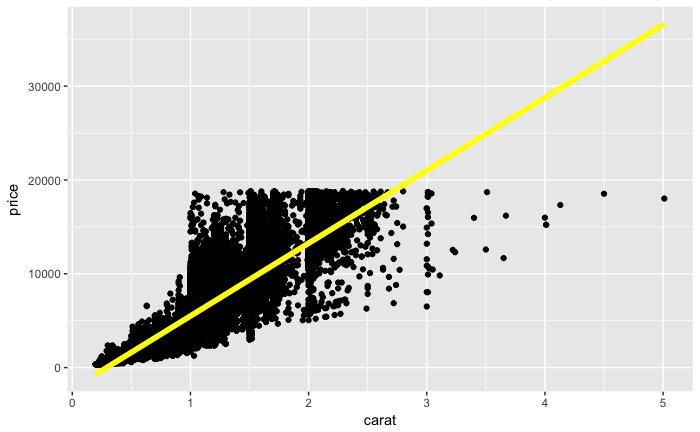

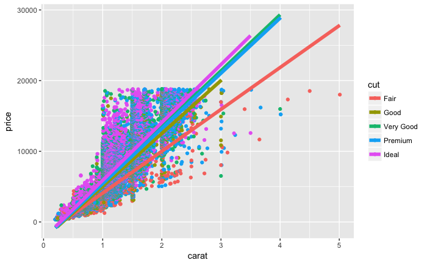

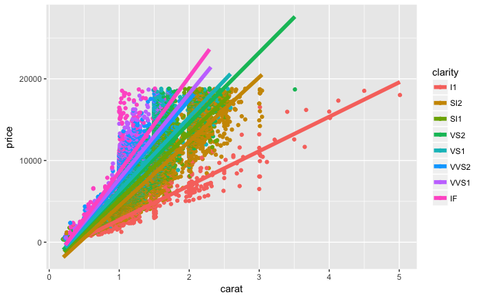

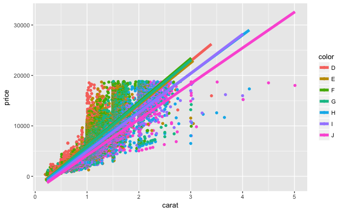

Price rises sharper for higher quality diamonds!

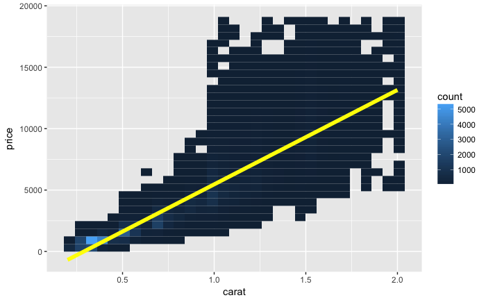

```r
ggplot(diamonds %>% filter(carat <= 2), aes(carat, price)) +
  geom_bin2d() +
  geom_smooth(method = "lm", se = FALSE, size = 2, colour = "yellow")
```

```r
model <- lm(price ~ carat, data = diamonds)
summary(model)
coef(summary(model))
summary(resid(mod))
ggplot(diamonds %>% mutate(rel_price = resid(mod)), aes(carat, rel_price)) + geom_point()
ggplot(diamonds %>% mutate(rel_price = resid(mod)), aes(carat, rel_price)) + geom_bin2d()
```

[output not shown]

We can use a linear model to remove the effect of size on price. Instead of looking at the raw price, we can look at the relative price: how valuable is this diamond relative to the average diamond of the same size.

| carat | cut | color | clarity | depth | table | price | x | y | z | lcarat | lprice |
| --- | --- | --- | --- | --- | --- | --- | --- | --- | --- | --- | --- |
| 0.23 | Ideal | E | SI2 | 61.5 | 55.0 | 326 | 3.95 | 3.98 | 2.43 | -2.12029423 | 8.348728 |
| 0.21 | Premium | E | SI1 | 59.8 | 61.0 | 326 | 3.89 | 3.84 | 2.31 | -2.25153877 | 8.348728 |
| 0.23 | Good | E | VS1 | 56.9 | 65.0 | 327 | 4.05 | 4.07 | 2.31 | -2.12029423 | 8.353147 |
| 0.29 | Premium | I | VS2 | 62.4 | 58.0 | 334 | 4.20 | 4.23 | 2.63 | -1.78587519 | 8.383704 |
| 0.31 | Good | J | SI2 | 63.3 | 58.0 | 335 | 4.34 | 4.35 | 2.75 | -1.68965988 | 8.388017 |
| 0.24 | Very Good | J | VVS2 | 62.8 | 57.0 | 336 | 3.94 | 3.96 | 2.48 | -2.05889369 | 8.392317 |
| 0.24 | Very Good | I | VVS1 | 62.3 | 57.0 | 336 | 3.95 | 3.98 | 2.47 | -2.05889369 | 8.392317 |
| 0.26 | Very Good | H | SI1 | 61.9 | 55.0 | 337 | 4.07 | 4.11 | 2.53 | -1.94341647 | 8.396605 |
| 0.22 | Fair | E | VS2 | 65.1 | 61.0 | 337 | 3.87 | 3.78 | 2.49 | -2.18442457 | 8.396605 |
| 0.23 | Very Good | H | VS1 | 59.4 | 61.0 | 338 | 4.00 | 4.05 | 2.39 | -2.12029423 | 8.400879 |

[output cut: 990 more lines]

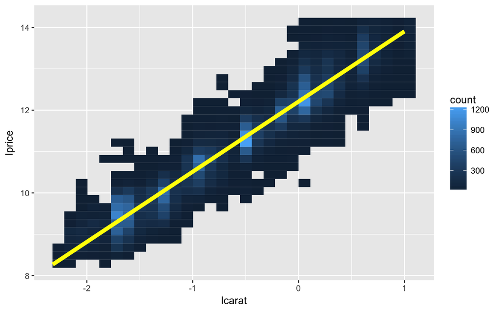

```
Call:
lm(formula = lprice ~ lcarat, data = diamonds2)

Residuals:
     Min       1Q   Median       3Q      Max
-1.97977 -0.25004 -0.01116  0.24384  1.94623

Coefficients:
             Estimate Std. Error t value Pr(>|t|)
(Intercept) 12.208920   0.002109  5789.0   <2e-16 ***
lcarat       1.696590   0.002078   816.3   <2e-16 ***
---
Signif. codes:  0 ‘***’ 0.001 ‘**’ 0.01 ‘*’ 0.05 ‘.’ 0.1 ‘ ’ 1

Residual standard error: 0.377 on 52049 degrees of freedom
Multiple R-squared:  0.9275,    Adjusted R-squared:  0.9275
F-statistic: 6.663e+05 on 1 and 52049 DF,  p-value: < 2.2e-16

            Estimate  Std. Error   t value Pr(>|t|)
(Intercept) 12.20892 0.002108989 5788.9930        0
lcarat       1.69659 0.002078441  816.2798        0
```

### Residuals

residuals are the vertical distance between each point and the line of best fit.

A relative price of zero means that the diamond was at the average price; positive means that it’s means that it’s more expensive than expected (based on its size), and negative means that it’s cheaper than expected.

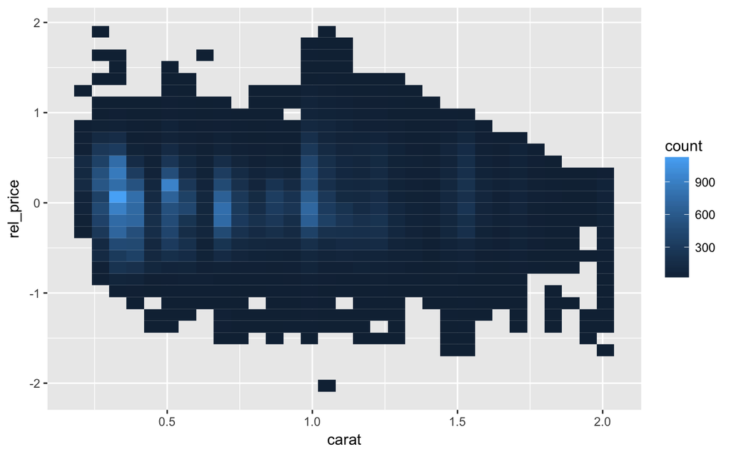

```r
diamonds2 <- diamonds2 %>% mutate(rel_price = resid(mod))
ggplot(diamonds2, aes(carat, rel_price)) +
  geom_bin2d()
```

```r
xgrid <- seq(-2, 1, by = 1/3)
data.frame(logx = xgrid, x = round(2 ^ xgrid, 2))
```

| logx | x |
| --- | --- |
| -2.0000000 | 0.25 |
| -1.6666667 | 0.31 |
| -1.3333333 | 0.40 |
| -1.0000000 | 0.50 |
| -0.6666667 | 0.63 |
| -0.3333333 | 0.79 |
| 0.0000000 | 1.00 |
| 0.3333333 | 1.26 |
| 0.6666667 | 1.59 |
| 1.0000000 | 2.00 |

```r
color_cut <- diamonds2 %>%
  group_by(color, cut) %>%
  summarise(
    price = mean(price),
    rel_price = mean(rel_price)
  )
color_cut
```

| color | cut | price | rel_price |
| --- | --- | --- | --- |
| D | Fair | 3939.013 | -0.07553480 |
| D | Good | 3308.968 | -0.04724615 |
| D | Very Good | 3368.184 | 0.10378073 |
| D | Premium | 3513.020 | 0.10929565 |
| D | Ideal | 2595.080 | 0.21731017 |
| E | Fair | 3515.823 | -0.17199301 |
| E | Good | 3314.239 | -0.05391991 |
| E | Very Good | 3101.343 | 0.06552333 |
| E | Premium | 3343.641 | 0.08445044 |
| E | Ideal | 2564.171 | 0.17390694 |

[output cut: 25 more lines]

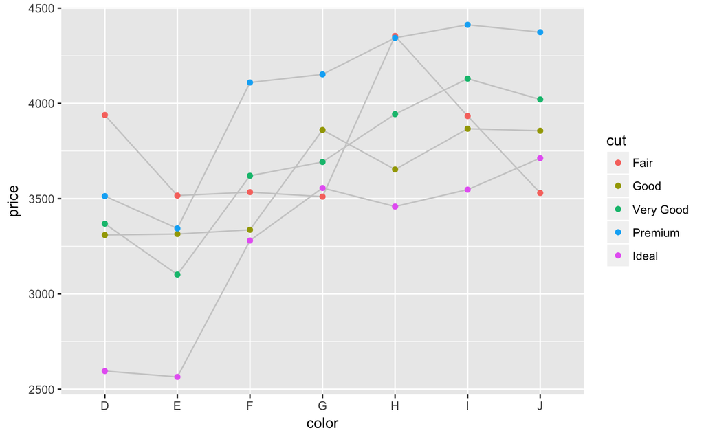

```r
ggplot(color_cut, aes(color, price)) +
  geom_line(aes(group = cut), colour = "grey80") +
  geom_point(aes(colour = cut))
```

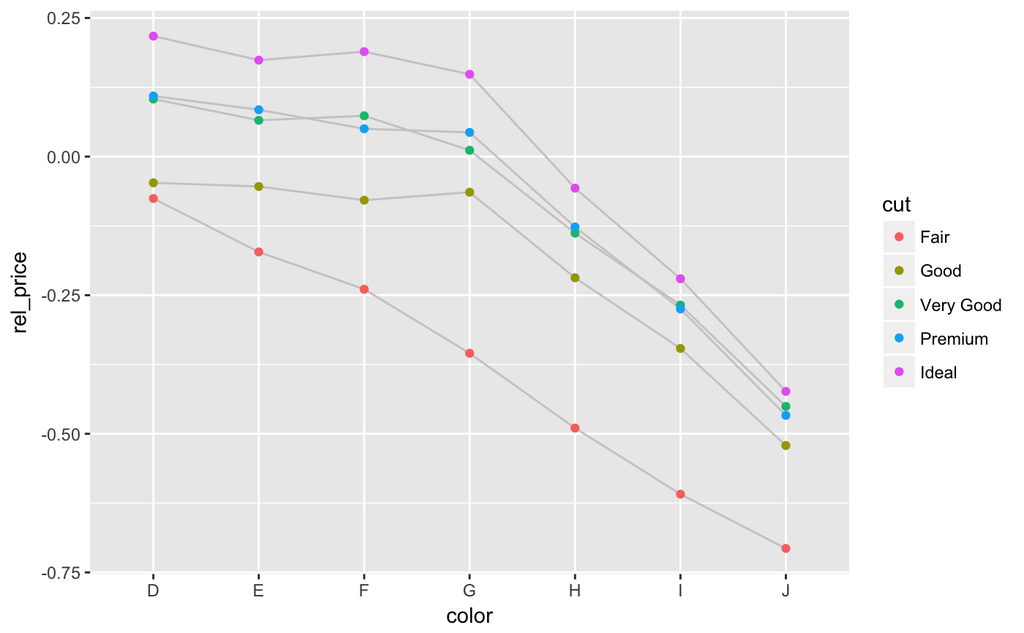

```r
ggplot(color_cut, aes(color, rel_price)) +
  geom_line(aes(group = cut), colour = "grey80") +
  geom_point(aes(colour = cut))
```

## Exercises

What happens if you repeat the above analysis with all diamonds? (Not just all diamonds with two or fewer carats).

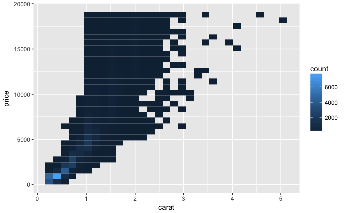

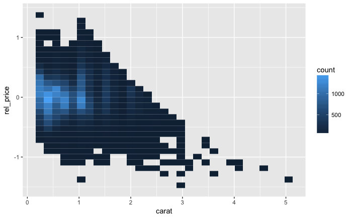

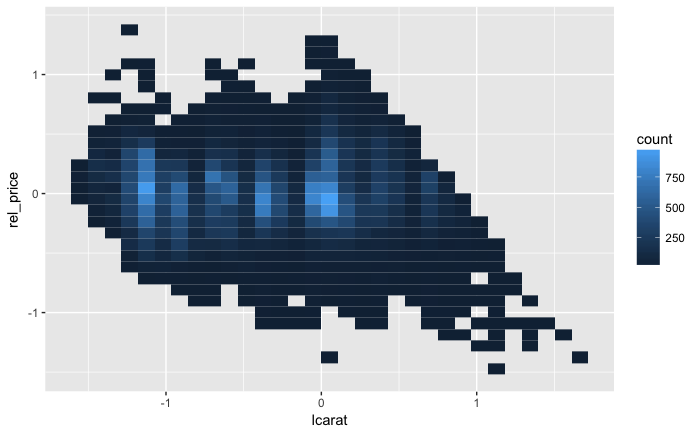

```r
ggplot(ldiamonds, aes(carat, price)) + geom_bin2d()
ggplot(ldiamonds, aes(carat, rel_price)) + geom_bin2d()

ggplot(ldiamonds, aes(lcarat, rel_price)) + geom_bin2d()
```

## What does the strange geometry of log(carat) vs relative price represent?

The largest diamonds tend to be cheaper than average because they are typically of lower quality

Are Lower quality Diamonds are larger ?

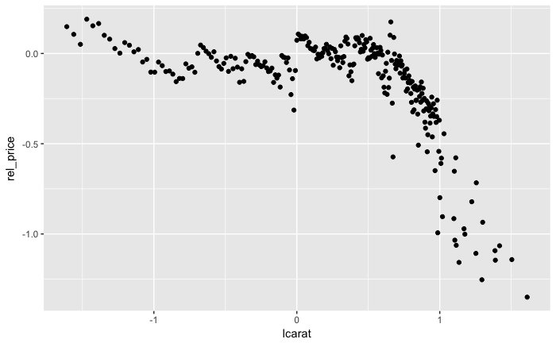

```r
by_carat <- ldiamonds %>% group_by(lcarat) %>%
  summarise(price = mean(price),
            rel_price = mean(rel_price))
ggplot(by_carat, aes(lcarat, rel_price)) + geom_point()
```

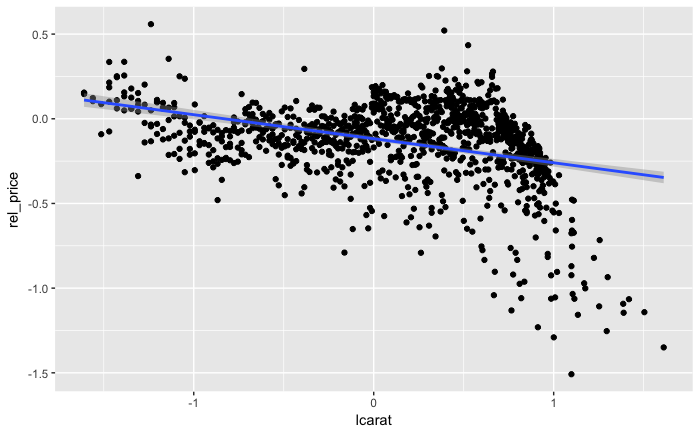

```r
by_carat_cut <- ldiamonds %>% group_by(lcarat, cut) %>%
  summarise(price = mean(price),
            rel_price = mean(rel_price))
ggplot(by_carat_cut, aes(lcarat, rel_price)) + geom_point() + geom_smooth(method = "lm")
```

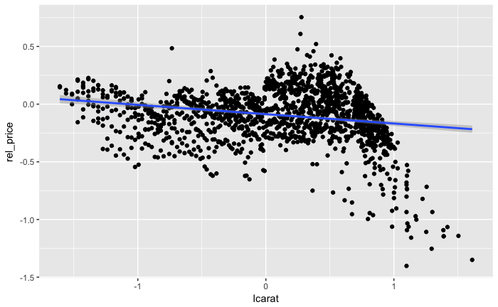

```r
by_carat_color <- ldiamonds %>% group_by(lcarat, color) %>%
  summarise(price = mean(price), rel_price = mean(rel_price))
ggplot(by_carat_color, aes(lcarat, rel_price)) + geom_point()  + geom_smooth(method = "lm")
```

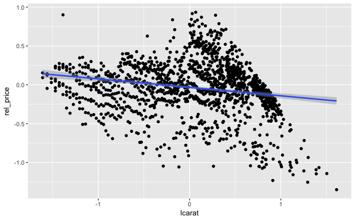

```r
by_carat_clarity <- ldiamonds %>% group_by(lcarat, clarity) %>%
  summarise(price = mean(price), rel_price = mean(rel_price))
ggplot(by_carat_clarity, aes(lcarat, rel_price)) + geom_point()  + geom_smooth(method = "lm")
```

## I made an unsupported assertion that lower-quality diamonds tend to be larger. Support my claim with a plot.

Yes for clarity and color, less so for cut

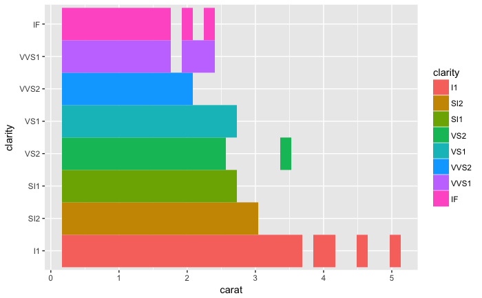

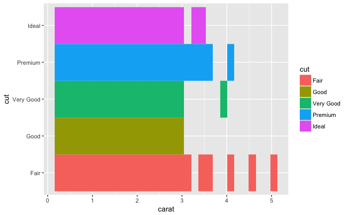

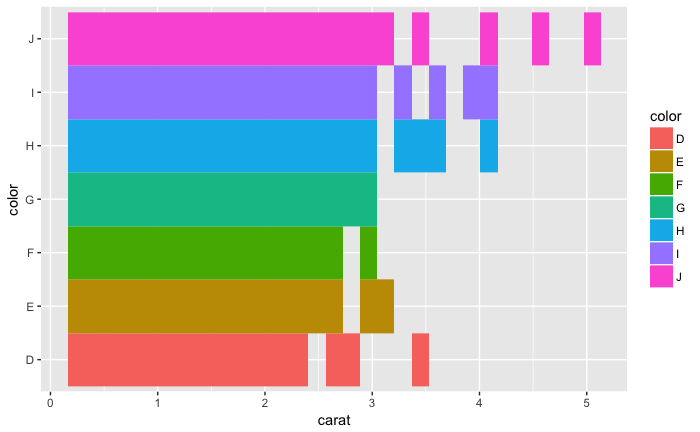

```r
ggplot(diamonds, aes(carat, clarity, fill = clarity)) + geom_bin2d()
ggplot(diamonds, aes(carat, cut, fill = cut)) + geom_bin2d()

ggplot(diamonds, aes(carat, color, fill = color)) + geom_bin2d()
```

How do depth and table relate to the relative price?

# Depth - no linear relationship

```r
summary(model)
```

```
Call:
lm(formula = log(price) ~ depth, data = diamonds)

Residuals:
     Min       1Q   Median       3Q      Max
-1.99972 -0.93011 -0.00285  0.79332  2.05680

Coefficients:
             Estimate Std. Error t value Pr(>|t|)
(Intercept) 7.7491526  0.1883591   41.14   <2e-16 ***
depth       0.0006092  0.0030496    0.20    0.842
---
Signif. codes:  0 ‘***’ 0.001 ‘**’ 0.01 ‘*’ 0.05 ‘.’ 0.1 ‘ ’ 1

Residual standard error: 1.015 on 53938 degrees of freedom
Multiple R-squared:  7.398e-07, Adjusted R-squared:  -1.78e-05
F-statistic: 0.0399 on 1 and 53938 DF,  p-value: 0.8417
```

```r
cor(diamonds$price, diamonds$table)
```

```
[1] 0.1271339
```

```r
cor(log(diamonds$price), diamonds$table)
```

```
[1] 0.1582079
```

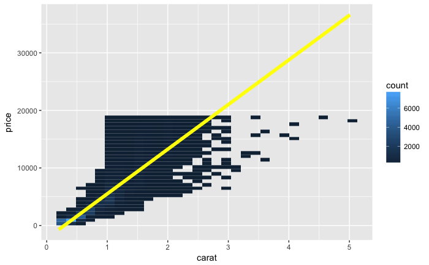

```r
ggplot(diamonds, aes(carat, price)) +
  geom_bin2d() +
  geom_smooth(method = "lm", se = FALSE, size = 2, color = "Yellow")
```

```r
ldiamonds <- diamonds %>% mutate(lcarat = log(carat), lprice = log(price))
model <- lm(lprice ~ lcarat, data = ldiamonds)
coef(summary(model))
```

```
            Estimate  Std. Error   t value Pr(>|t|)
(Intercept) 8.448661 0.001364691 6190.8959        0
lcarat      1.675817 0.001933806  866.5901        0
```

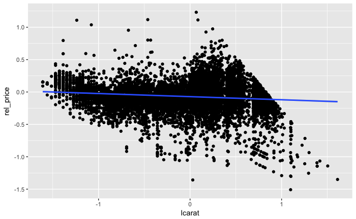

```r
ldiamonds <- ldiamonds %>% mutate(rel_price = resid(model))
by_carat_depth <- ldiamonds %>% group_by(lcarat, depth) %>%
  summarise(price = mean(price), rel_price = mean(rel_price))
ggplot(by_carat_depth, aes(lcarat, rel_price)) + geom_point() + geom_smooth(method = "lm")
```

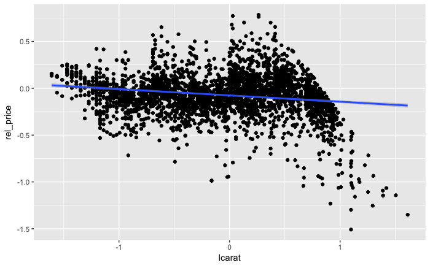

```r
by_carat_table <- ldiamonds %>% group_by(lcarat, table) %>%
  summarise(price = mean(price), rel_price = mean(rel_price))
ggplot(by_carat_table, aes(lcarat, rel_price)) + geom_point() + geom_smooth(method = "lm")
```